# STATS 250 Lab 2

Lab Dream Team

Week of 2/1/2021

# Learning Objectives

## R Learning Objectives

1. Learn how to make a bar chart in R
2. Learn how to make a frequency table and a two-way frequency table in R
3. Learn how to make a boxplot in R
4. Learn how to find the five-number summary of a variable, and find a specific numeric summary in R
5. Learn how to make a histogram in R

## Functions covered in this lab

1. `table()`
2. `barplot()`
3. `summary()`
4. `boxplot()`
5. `min()`, `mean()`, `median()`, `max()`, `sd()`, `IQR()`
6. `hist()`

# Lab Tutorial

We’re back to hanging out with our penguin friends.

```r
penguins <- read.csv("penguins.csv")
```

As we learned last week, this data set has several variables, some categorical, and some quantitative. We will discuss how to visualize both categorical and quantitative data.

## Frequency Tables

Let’s start with the `species` variable. Is this a categorical or quantitative variable? How do you know?

To make a frequency table of a categorical variable, we use the `table()` function:

```r
table(penguins$species)
```

```
##
##    Adelie Chinstrap    Gentoo
##       146        68       119
```

So, there are 119 Gentoo penguins in the data.

Notice that inside the table function, we have something that looks a little weird. We wrote `penguins$species`. This is how we tell R to use the `species` variable *inside the data frame* `penguins`. The dollar sign ($) tells R to look inside the data frame `penguins` for the column called `species`.

It’s very important that you tell R *which data frame* the variable you’re interested in is from. Let’s see what happens when we don’t:

```r
species
```

```
## Error in eval(expr, envir, enclos): object 'species' not found
```

Because we don’t have anything called `species` in our environment (there’s nothing called `species` in the environment pane), R doesn’t know what we’re talking about! `species` only exists inside of `penguins`.

We can also make “two-way” frequency tables (sometimes called “contingency tables”) to summarize counts for two categorical variables:

```r
table(penguins$species, penguins$island)
```

```
##
##             Biscoe Dream Torgersen
##   Adelie        44    55        47
##   Chinstrap      0    68         0
##   Gentoo       119     0         0
```

So it looks like all the Gentoo penguins in our data live on Biscoe island.

Remember that data is **r**eally **c**ool, so the first variable you give to `table()` is in the **r**ows of the table, and the second is in the **c**olumns.

Notice that we separated the two variables inside of `table()` with a comma – it’s important to remember this! Each of these variables is an *argument* to the `table()` function, and we separate arguments with commas.

## Bar Charts in R

Let’s explore our `penguins` data by making a plot that will help us visualize a categorical variable. We’ll start by looking at the number of penguins observed of each species.

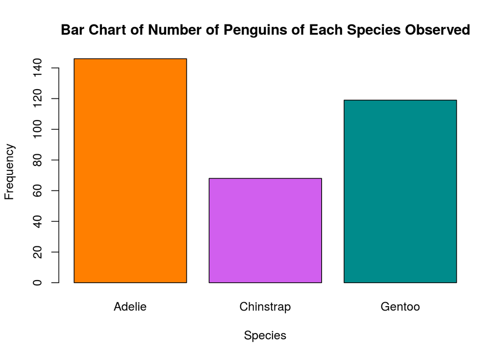

```r
barplot(table(penguins$species),
     xlab = "Species",
     ylab = "Frequency",
     main = "Bar Chart of Number of Penguins of Each Species Observed",
     col = c("darkorange1", "mediumorchid2", "darkcyan"))
```

Notice that we included the table from earlier in our code! This is how we will make a Bar Chart in R. Also notice that we included some arguments, such as `xlab`, the label on the x (or horizontal) axis, `ylab`, the label on the y (or vertical) axis, `main`, the title of the graph, and a nice way to add some fun to an otherwise boring plot - `col` for colors. We have three species of penguins, so we picked out three colors that we thought best represented each species. There are lots and lots of colors that you can try. We will show you more about colors next week!

## Numerical Summaries

Let’s start with the `flipper_length_mm` variable. Is this a categorical or quantitative variable? How do you know?

We can use R to summarize data numerically. We’ll use the `summary()` function to do that for a given variable. Here, we’ll summarize the `flipper_length_mm` variable, which is the length of the penguins’ flippers (in millimeters).

```r
summary(penguins$flipper_length_mm)
```

```
##    Min. 1st Qu.  Median    Mean 3rd Qu.    Max.
##     172     190     197     201     213     231
```

R gives us 6 numbers: the minimum (shortest) flipper length, the first quartile, the median (middle) flipper length, the mean (average) flipper length, the third quartile, and the maximum (longest) flipper length.

You can always get just the one numerical summary you’re looking for using the function for that specific summary:

```r
min(penguins$flipper_length_mm)
```

```
## [1] 172
```

```r
mean(penguins$flipper_length_mm)
```

```
## [1] 200.967
```

```r
median(penguins$flipper_length_mm)
```

```
## [1] 197
```

```r
max(penguins$flipper_length_mm)
```

```
## [1] 231
```

```r
sd(penguins$flipper_length_mm)
```

```
## [1] 14.01577
```

```r
IQR(penguins$flipper_length_mm)
```

```
## [1] 23
```

## Boxplots in R

One type of graphical display for a quantitative variable is a boxplot. The command for making a boxplot in R is pretty simple: it’s just `boxplot()`. To make a boxplot of a single variable, just give R the name of the data set, a dollar sign ($), then the name of the variable. Also provide the arguments `main` and `ylab` for a plot title and y-axis label.

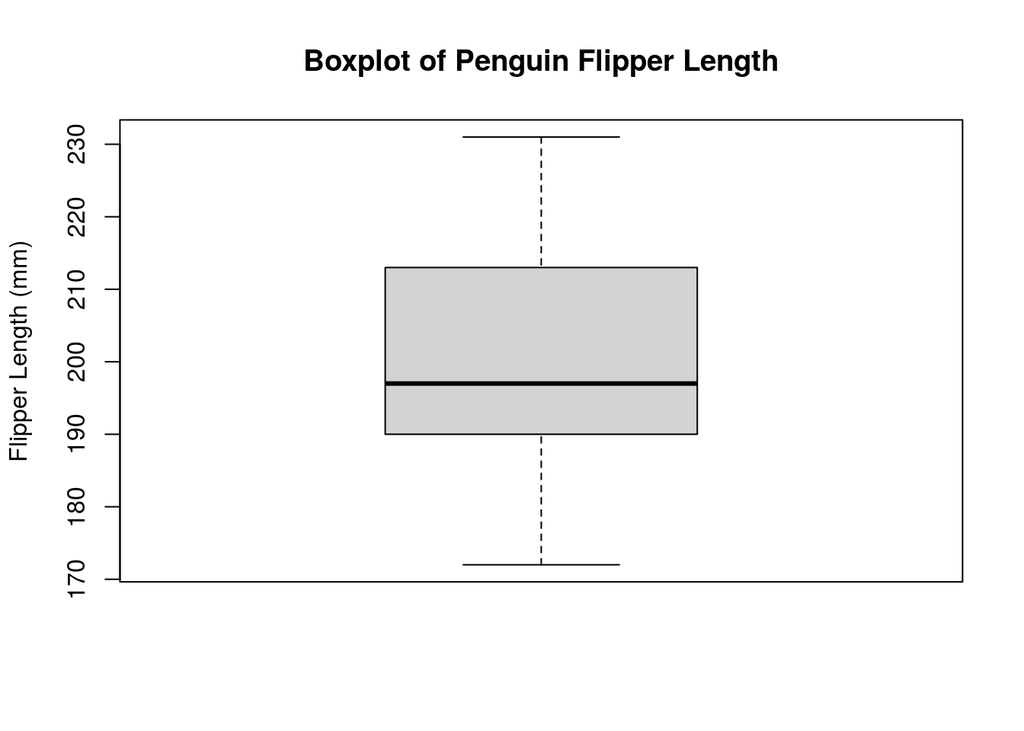

```r
boxplot(penguins$flipper_length_mm,
        main = "Boxplot of Penguin Flipper Length",
        ylab = "Flipper Length (mm)")
```

## Histograms in R

Another type of graphical display for a quantitative variable is a histogram. Histograms in R are also pretty easy – you just use the `hist()` function.

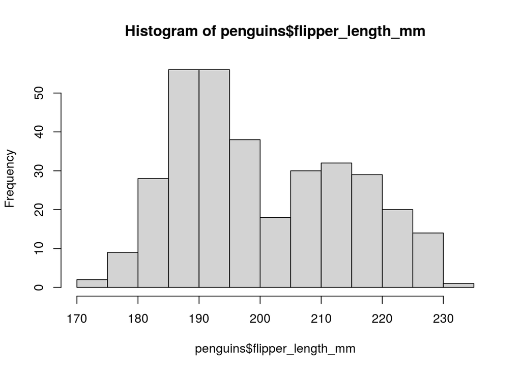

```r
hist(penguins$flipper_length_mm)
```

So here we’ve got a histogram. Notice that we didn’t provide the `main`, `xlab`, and `ylab` arguments that we’d normally use for a plot title and an axis label, but R still gave us a title and labels. This is nice, but the labels are *horrible*: nobody (other than you) knows what `penguin$flipper_length_mm` means, so we don’t want to use that as a title or axis label. The moral of the story is to *always provide `main`, `xlab`, and `ylab` arguments when making a plot!*

Here’s something better:

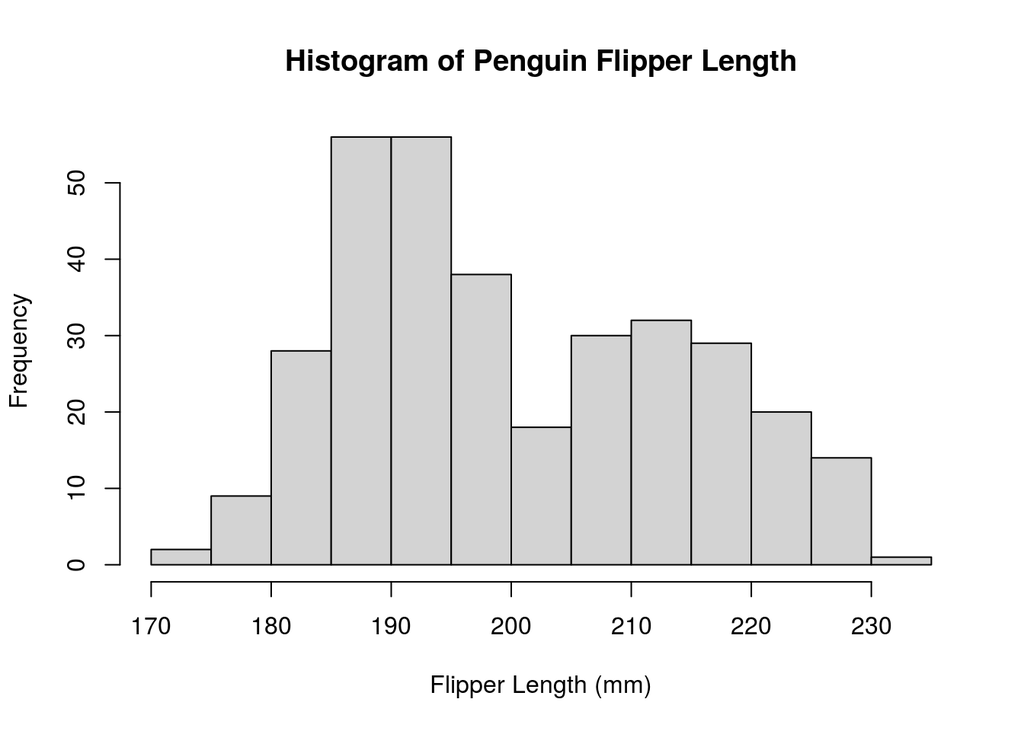

```r
hist(penguins$flipper_length_mm,
     main = "Histogram of Penguin Flipper Length",
     xlab = "Flipper Length (mm)")
```

## How to find help in R

R has built-in “documentation” for every function. If you want to find that documentation, you can Google it, but that takes too long. So it’s better to use R’s built in help! In the R console, just type a question mark `?` followed by the name of the function you want help with, then hit enter. For example, `?hist` will bring up the documentation for the `hist()` function.

At the end of the help file you *may* find an example of how to use the function. These examples are generally super helpful! You can directly run them using the `example()` function – e.g., `example(hist)`.

# Code Cheat Sheet

## `$`

- what is a dollar sign really
- `data_set_name$data_set_variable`

## `table(data_set_name$data_set_variable)`

- creates a table of the frequencies of one categorical variable

## `table(data_set_name$data_set_variable, data_set_name$data_set_variable)`

- creates a two way table of the frequencies of two categorical variables

## `barplot(table(data_set_name$data_set_variable))`

- creates a barplot of a categorical variable

## `summary(data_set_name$data_set_variable)`

- creates the five number summary of a quantitative variable

## `hist(data_set_name$data_set_variable)`

- creates a histogram of a quantitative variable

## `boxplot(data_set_name$data_set_variable)`

- creates a boxplot of a quantitative variable

## Important plotting arguments

### `main = "Title of Your Graph in Double Quotes"`

- graph title that must be inside a set of double quotes

### `xlab = "x-axis Label of Your Graph in Double Quotes"`

- the x- (horizontal) axis label that must be inside a set of double quotes

### `ylab = "y-axis Label of Your Graph in Double Quotes"`

- the y- (vertical) axis label that must be inside a set of double quotes